# Session 2: Subsets and Plots

Isabelle Laforest-Lapointe

2025-05-05

## Importing data

First, you want to import your data. It is important to create objects with explicit and short names, that are not already built-in functions in R. Ex: do not create a data named data or summary or plot.

```r
#tomato_data_2025_ILL_test_repeat<-read.csv("Rocio_tomato_modified.csv")
tomato<-read.csv("Rocio_tomato_modified.csv")
```

## Exploring data

The function summary() is very useful to explore what is in your data and also to confirm that your data was imported well.

```r
summary(tomato)
```

```
##       rep        Treatement         Infection           total.area
##  Min.   :1.00   Length:48          Length:48          Min.   :1034441
##  1st Qu.:1.75   Class :character   Class :character   1st Qu.:2194426
##  Median :2.50   Mode  :character   Mode  :character   Median :2856845
##  Mean   :2.50                                         Mean   :2646678
##  3rd Qu.:3.25                                         3rd Qu.:3291366
##  Max.   :4.00                                         Max.   :4389281
##  chlorotic.area
##  Min.   : 14666
##  1st Qu.: 31068
##  Median : 54448
##  Mean   : 81711
##  3rd Qu.: 87013
##  Max.   :365390
```

The head() and View() functions are also good ways to take a peek at your data.

```r
head(tomato)
```

```
##   rep Treatement Infection total.area chlorotic.area
## 1   1       mock     water    2663192          83409
## 2   1       mock     water    3466704         111165
## 3   1       mock     water    3604993          52202
## 4   1    treated     water    3605450          86927
## 5   1    treated     water    2323251          46141
## 6   1    treated     water    2938431          40150
```

## Formatting

Next, you will want to make sure that your variables are formatted adequately. Here, we have variables that are numeric (allowing for mathematical operations) and some that are factors (with levels). We will transform some in factors and take a look at the summary() to confirm the successful transformation.

```r
tomato$rep<-as.factor(tomato$rep)
tomato$Treatement<-as.factor(tomato$Treatement)
tomato$Infection<-as.factor(tomato$Infection)
summary(tomato)
```

```
##  rep      Treatement    Infection    total.area      chlorotic.area
##  1:12   mock   :24   pathogen:23   Min.   :1034441   Min.   : 14666
##  2:12   treated:24   pathogn : 1   1st Qu.:2194426   1st Qu.: 31068
##  3:12                water   :24   Median :2856845   Median : 54448
##  4:12                              Mean   :2646678   Mean   : 81711
##                                    3rd Qu.:3291366   3rd Qu.: 87013
##                                    Max.   :4389281   Max.   :365390
```

We can observe quickly that a typo is now present in our data. We could either correct it in the raw data file and reimport a new object, or correct it in R using the which() function and dimensionality operators.

```r
which(tomato$Infection=="pathogn") #find the position of the error in the variable
```

```
## [1] 10
```

```r
tomato$Infection[10] #confirm that this is the error
```

```
## [1] pathogn
## Levels: pathogen pathogn water
```

```r
tomato$Infection[10]<-"pathogen" #correct the error FOREVER by overwritting
tomato$Infection<-droplevels(tomato$Infection) #erase the empty factor level
summary(tomato) #check the summary again
```

```
##  rep      Treatement    Infection    total.area      chlorotic.area
##  1:12   mock   :24   pathogen:24   Min.   :1034441   Min.   : 14666
##  2:12   treated:24   water   :24   1st Qu.:2194426   1st Qu.: 31068
##  3:12                              Median :2856845   Median : 54448
##  4:12                              Mean   :2646678   Mean   : 81711
##                                    3rd Qu.:3291366   3rd Qu.: 87013
##                                    Max.   :4389281   Max.   :365390
```

## Visualizing the data

Histograms are a fundamental tool in R for exploratory data analysis (EDA). They help you:

**Visualize Distributions:** Quickly see the shape of your data (e.g., normal, skewed, bimodal). **Spot Outliers & Gaps:** Identify unusual values or missing ranges in your dataset. **Check Assumptions:** Assess if data meets statistical assumptions (e.g., normality for t-tests). **Compare Groups:** Overlay histograms to compare different subsets (e.g., treatment vs. control).

In R, creating a histogram is simple (e.g., hist(data)), making it an essential first step in understanding your data before diving into analysis.

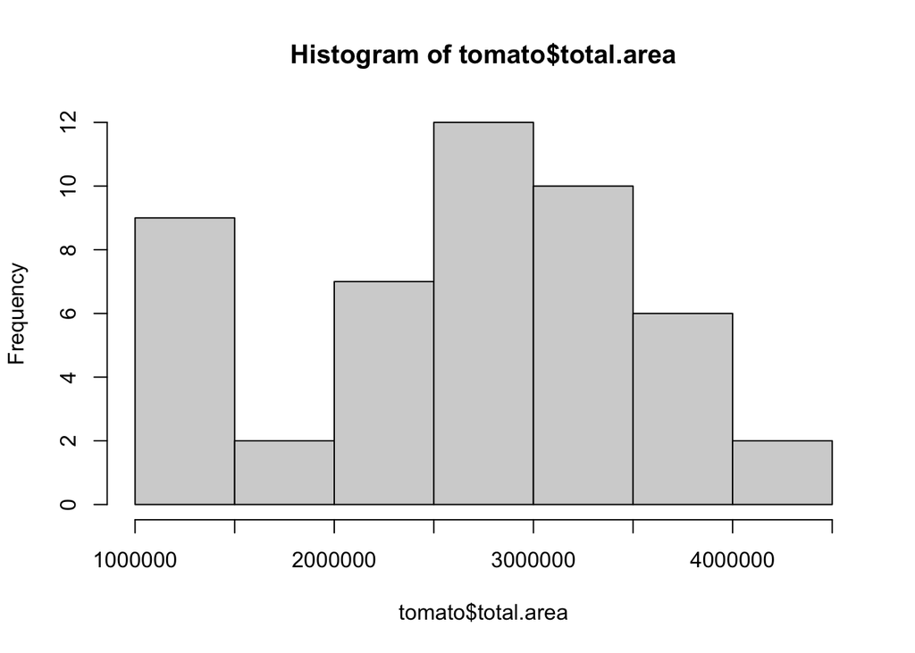

```r
hist(tomato$total.area)
```

Scatterplot and boxplots are also very common graphs to be performed to explore the data. Here are a few exemples:

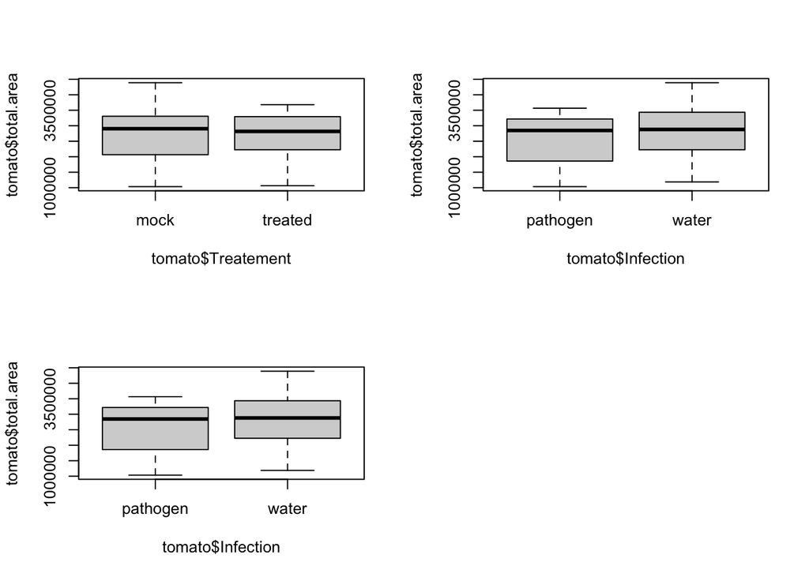

```r
par(mfrow=c(2,2))
plot(tomato$total.area~tomato$Treatement)
#plot(total.area~Treatement,data=tomato) #this is the same
plot(tomato$total.area~tomato$Infection)
plot(tomato$total.area~tomato$Infection)
```

What happens with an interaction?

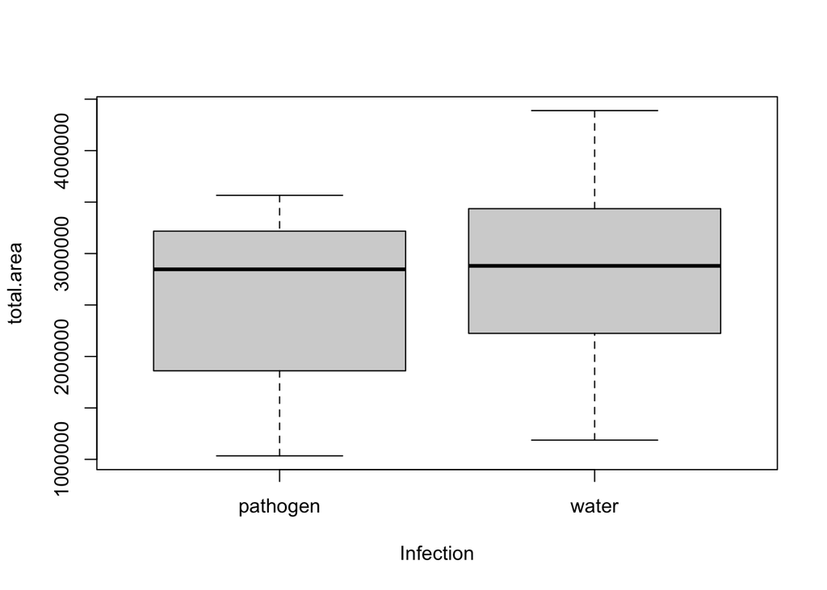

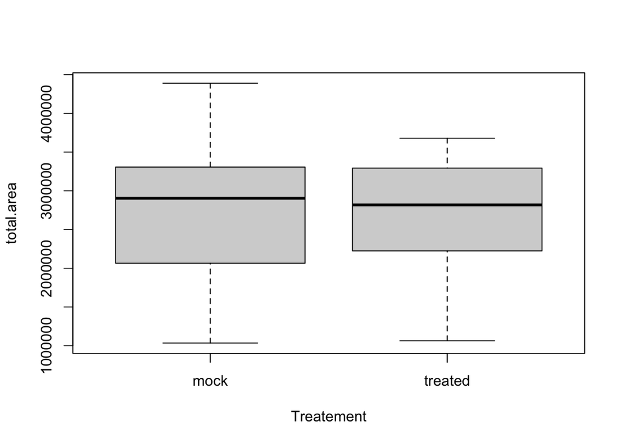

```r
plot(total.area~Infection*Treatement, data=tomato)
```

Here is a scatterplot:

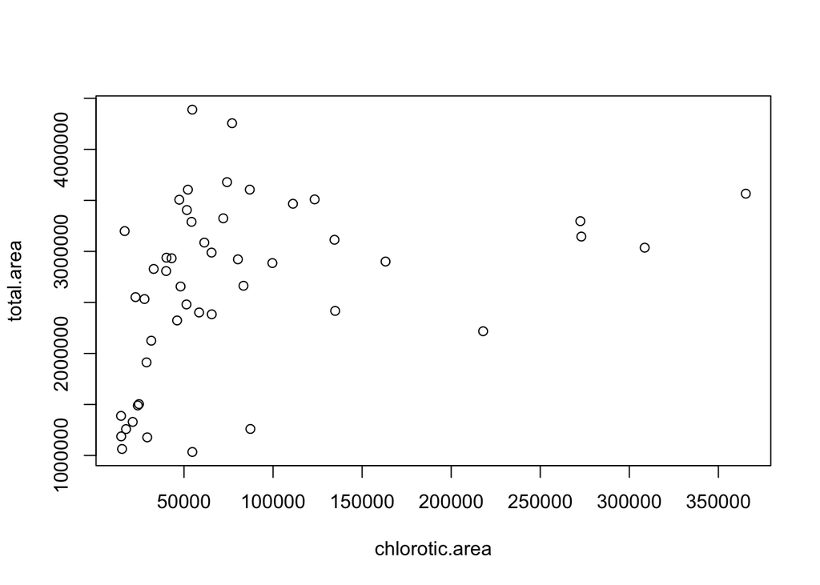

```r
plot(total.area~chlorotic.area, data=tomato)
```

You can apply transformation in your plot formula:

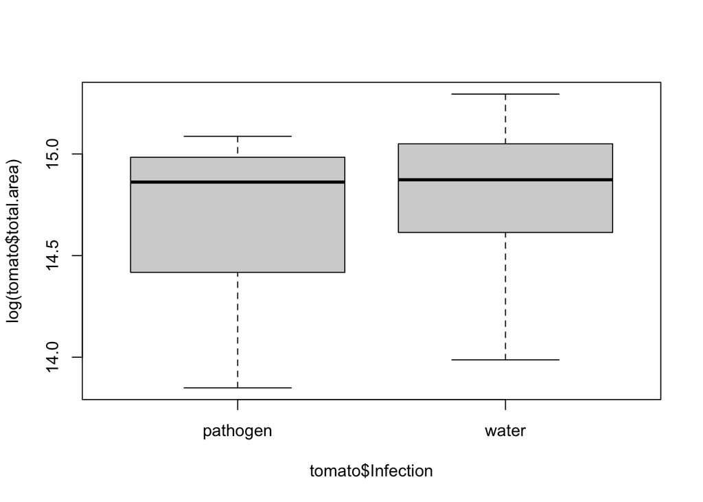

```r
plot(log(tomato$total.area)~tomato$Infection)
```

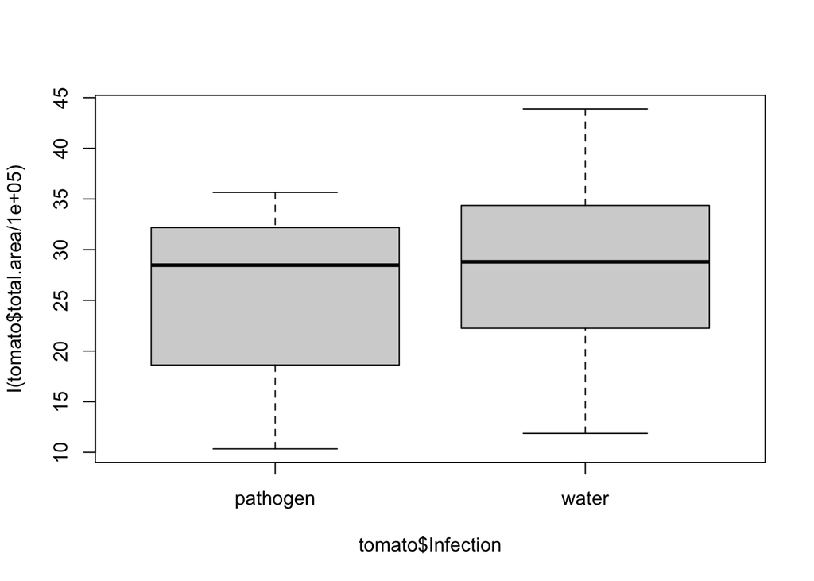

```r
plot(I(tomato$total.area/100000)~tomato$Infection)
```

We can create new variables that combine Treatement and Infection as well as the ratio between both areas, then use it for plotting:

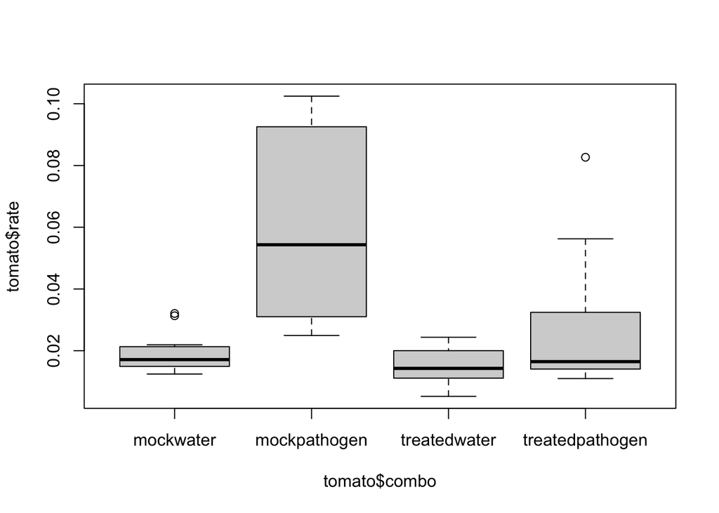

```r
tomato$combo<-as.factor(paste(tomato$Treatement,tomato$Infection,sep=""))
tomato$rate<-tomato$chlorotic.area/tomato$total.area
tomato$combo<-factor(tomato$combo,levels=levels(tomato$combo)[c(2,1,4,3)]) #here we reorder the levels
plot(tomato$rate~tomato$combo)
```

## Bonus

Create a dataset for each rep and plot the ratio between chlorotic.area/total.area for the for combined levels (combo).